# Risk Factor Analysis

## Outcome Variable

**Outcome Variable:** co24

## Predictor Variables

**Intervention Variable:** wast06

**Adjustment Set:**

unadjusted

## Stratifying Variables

The analysis was stratified on these variable(s):

- agecat
- studyid
- country

## Data Summary

| agecat | studyid | country | wast06 | co24 | n_cell | n |
| --- | --- | --- | --- | --- | --- | --- |
| 0-6 months | CMC-V-BCS-2002 | INDIA | 0 | 0 | 173 | 368 |
| 0-6 months | CMC-V-BCS-2002 | INDIA | 0 | 1 | 5 | 368 |
| 0-6 months | CMC-V-BCS-2002 | INDIA | 1 | 0 | 174 | 368 |
| 0-6 months | CMC-V-BCS-2002 | INDIA | 1 | 1 | 16 | 368 |
| 0-6 months | CMIN | BANGLADESH | 0 | 0 | 204 | 271 |
| 0-6 months | CMIN | BANGLADESH | 0 | 1 | 17 | 271 |
| 0-6 months | CMIN | BANGLADESH | 1 | 0 | 39 | 271 |
| 0-6 months | CMIN | BANGLADESH | 1 | 1 | 11 | 271 |
| 0-6 months | CONTENT | PERU | 0 | 0 | 211 | 215 |
| 0-6 months | CONTENT | PERU | 0 | 1 | 0 | 215 |
| 0-6 months | CONTENT | PERU | 1 | 0 | 4 | 215 |
| 0-6 months | CONTENT | PERU | 1 | 1 | 0 | 215 |
| 0-6 months | EE | PAKISTAN | 0 | 0 | 227 | 379 |
| 0-6 months | EE | PAKISTAN | 0 | 1 | 28 | 379 |
| 0-6 months | EE | PAKISTAN | 1 | 0 | 92 | 379 |
| 0-6 months | EE | PAKISTAN | 1 | 1 | 32 | 379 |
| 0-6 months | GMS-Nepal | NEPAL | 0 | 0 | 396 | 686 |
| 0-6 months | GMS-Nepal | NEPAL | 0 | 1 | 33 | 686 |
| 0-6 months | GMS-Nepal | NEPAL | 1 | 0 | 217 | 686 |
| 0-6 months | GMS-Nepal | NEPAL | 1 | 1 | 40 | 686 |
| 0-6 months | Guatemala BSC | GUATEMALA | 0 | 0 | 285 | 295 |
| 0-6 months | Guatemala BSC | GUATEMALA | 0 | 1 | 0 | 295 |
| 0-6 months | Guatemala BSC | GUATEMALA | 1 | 0 | 2 | 295 |
| 0-6 months | Guatemala BSC | GUATEMALA | 1 | 1 | 8 | 295 |
| 0-6 months | IRC | INDIA | 0 | 0 | 181 | 409 |
| 0-6 months | IRC | INDIA | 0 | 1 | 5 | 409 |
| 0-6 months | IRC | INDIA | 1 | 0 | 214 | 409 |
| 0-6 months | IRC | INDIA | 1 | 1 | 9 | 409 |
| 0-6 months | Keneba | GAMBIA | 0 | 0 | 1732 | 2462 |
| 0-6 months | Keneba | GAMBIA | 0 | 1 | 60 | 2462 |

[output cut: 54 more lines]

The following strata were considered:

- agecat: 0-6 months, studyid: CMC-V-BCS-2002, country: INDIA
- agecat: 0-6 months, studyid: CMIN, country: BANGLADESH
- agecat: 0-6 months, studyid: CONTENT, country: PERU
- agecat: 0-6 months, studyid: EE, country: PAKISTAN
- agecat: 0-6 months, studyid: GMS-Nepal, country: NEPAL
- agecat: 0-6 months, studyid: Guatemala BSC, country: GUATEMALA
- agecat: 0-6 months, studyid: IRC, country: INDIA
- agecat: 0-6 months, studyid: Keneba, country: GAMBIA
- agecat: 0-6 months, studyid: MAL-ED, country: BANGLADESH
- agecat: 0-6 months, studyid: MAL-ED, country: BRAZIL
- agecat: 0-6 months, studyid: MAL-ED, country: INDIA
- agecat: 0-6 months, studyid: MAL-ED, country: NEPAL
- agecat: 0-6 months, studyid: MAL-ED, country: PERU
- agecat: 0-6 months, studyid: MAL-ED, country: SOUTH AFRICA
- agecat: 0-6 months, studyid: MAL-ED, country: TANZANIA, UNITED REPUBLIC OF
- agecat: 0-6 months, studyid: PROVIDE, country: BANGLADESH
- agecat: 0-6 months, studyid: ResPak, country: PAKISTAN
- agecat: 0-6 months, studyid: TanzaniaChild2, country: TANZANIA, UNITED REPUBLIC OF
- agecat: 18-24 months, studyid: CMC-V-BCS-2002, country: INDIA
- agecat: 18-24 months, studyid: IRC, country: INDIA
- agecat: 18-24 months, studyid: Keneba, country: GAMBIA

### Dropped Strata

Some strata were dropped due to rare outcomes:

- agecat: 0-6 months, studyid: CONTENT, country: PERU
- agecat: 0-6 months, studyid: Guatemala BSC, country: GUATEMALA
- agecat: 0-6 months, studyid: MAL-ED, country: BRAZIL
- agecat: 0-6 months, studyid: MAL-ED, country: NEPAL
- agecat: 0-6 months, studyid: MAL-ED, country: PERU
- agecat: 0-6 months, studyid: MAL-ED, country: SOUTH AFRICA
- agecat: 0-6 months, studyid: MAL-ED, country: TANZANIA, UNITED REPUBLIC OF
- agecat: 0-6 months, studyid: ResPak, country: PAKISTAN
- agecat: 18-24 months, studyid: CMC-V-BCS-2002, country: INDIA
- agecat: 18-24 months, studyid: IRC, country: INDIA
- agecat: 18-24 months, studyid: Keneba, country: GAMBIA

## Methods Detail

We’re interested in the causal parameters $E[Y_a]$ for all values of $a \in \mathcal{A}$. These parameters represent the mean outcome if, possibly contrary to fact, we intervened to set all units to have $A=a$. Under the randomization and positivity assumptions, these are identified by the statistical parameters $\psi_a=E_W[E_{Y|A,W}(Y|A=a,W)]$. In addition, we’re interested in the mean of $Y$, $E[Y]$ under no intervention (the observed mean). We will estimate these parameters by using SuperLearner to fit the relevant likelihood factors – $E_{Y|A,W}(Y|A=a,W)$ and $p(A=a|W)$, and then updating our likelihood fit using a joint TMLE.

For unadjusted analyses ($W=\{\}$), initial likelihoods were estimated using Lrnr_glm to estimate the simple $E(Y|A)$ and Lrnr_mean to estimate $p(A)$. For adjusted analyses, a small library containing Lrnr_glmnet, Lrnr_xgboost, and Lrnr_mean was used.

Having estimated these parameters, we will then use the delta method to estimate relative risks and attributable risks relative to a prespecified baseline level of $A$.

# Results Detail

## Results Plots

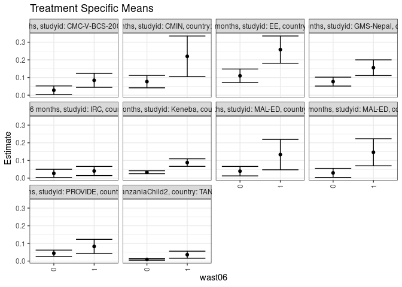

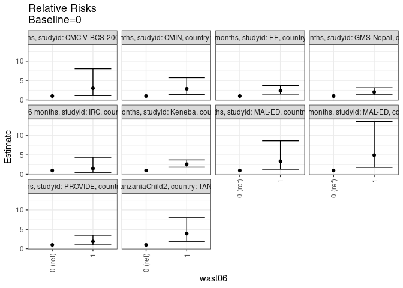

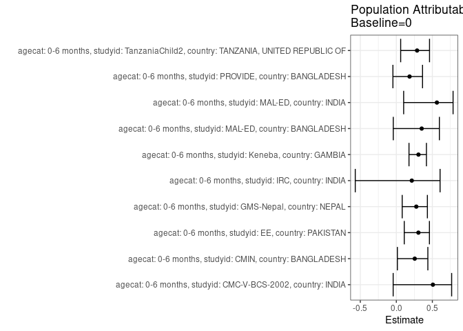

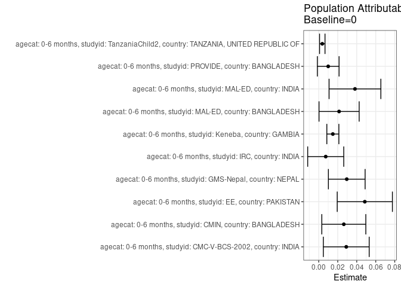

## Results Table

### Parameter: TSM

| agecat | studyid | country | intervention_level | baseline_level | estimate | ci_lower | ci_upper |
| --- | --- | --- | --- | --- | --- | --- | --- |
| 0-6 months | CMC-V-BCS-2002 | INDIA | 0 | NA | 0.0280899 | 0.0037837 | 0.0523961 |
| 0-6 months | CMC-V-BCS-2002 | INDIA | 1 | NA | 0.0842105 | 0.0446699 | 0.1237511 |
| 0-6 months | CMIN | BANGLADESH | 0 | NA | 0.0769231 | 0.0417264 | 0.1121198 |
| 0-6 months | CMIN | BANGLADESH | 1 | NA | 0.2200000 | 0.1049665 | 0.3350335 |
| 0-6 months | EE | PAKISTAN | 0 | NA | 0.1098039 | 0.0713798 | 0.1482280 |
| 0-6 months | EE | PAKISTAN | 1 | NA | 0.2580645 | 0.1809461 | 0.3351829 |
| 0-6 months | GMS-Nepal | NEPAL | 0 | NA | 0.0769231 | 0.0516892 | 0.1021569 |
| 0-6 months | GMS-Nepal | NEPAL | 1 | NA | 0.1556420 | 0.1112888 | 0.1999952 |
| 0-6 months | IRC | INDIA | 0 | NA | 0.0268817 | 0.0036097 | 0.0501538 |
| 0-6 months | IRC | INDIA | 1 | NA | 0.0403587 | 0.0144974 | 0.0662201 |
| 0-6 months | Keneba | GAMBIA | 0 | NA | 0.0334821 | 0.0251515 | 0.0418128 |
| 0-6 months | Keneba | GAMBIA | 1 | NA | 0.0880597 | 0.0665977 | 0.1095217 |
| 0-6 months | MAL-ED | BANGLADESH | 0 | NA | 0.0394089 | 0.0125929 | 0.0662248 |
| 0-6 months | MAL-ED | BANGLADESH | 1 | NA | 0.1333333 | 0.0471556 | 0.2195111 |
| 0-6 months | MAL-ED | INDIA | 0 | NA | 0.0295858 | 0.0039886 | 0.0551830 |
| 0-6 months | MAL-ED | INDIA | 1 | NA | 0.1463415 | 0.0696876 | 0.2229953 |
| 0-6 months | PROVIDE | BANGLADESH | 0 | NA | 0.0443160 | 0.0265981 | 0.0620339 |
| 0-6 months | PROVIDE | BANGLADESH | 1 | NA | 0.0828729 | 0.0426809 | 0.1230650 |
| 0-6 months | TanzaniaChild2 | TANZANIA, UNITED REPUBLIC OF | 0 | NA | 0.0092099 | 0.0050869 | 0.0133328 |
| 0-6 months | TanzaniaChild2 | TANZANIA, UNITED REPUBLIC OF | 1 | NA | 0.0360360 | 0.0160137 | 0.0560584 |

### Parameter: E(Y)

| agecat | studyid | country | intervention_level | baseline_level | estimate | ci_lower | ci_upper |
| --- | --- | --- | --- | --- | --- | --- | --- |
| 0-6 months | CMC-V-BCS-2002 | INDIA | NA | NA | 0.0570652 | 0.0333328 | 0.0807976 |
| 0-6 months | CMIN | BANGLADESH | NA | NA | 0.1033210 | 0.0670150 | 0.1396271 |
| 0-6 months | EE | PAKISTAN | NA | NA | 0.1583113 | 0.1215125 | 0.1951102 |
| 0-6 months | GMS-Nepal | NEPAL | NA | NA | 0.1064140 | 0.0833215 | 0.1295065 |
| 0-6 months | IRC | INDIA | NA | NA | 0.0342298 | 0.0165874 | 0.0518722 |
| 0-6 months | Keneba | GAMBIA | NA | NA | 0.0483347 | 0.0398612 | 0.0568082 |
| 0-6 months | MAL-ED | BANGLADESH | NA | NA | 0.0608365 | 0.0318931 | 0.0897799 |
| 0-6 months | MAL-ED | INDIA | NA | NA | 0.0677291 | 0.0365806 | 0.0988776 |
| 0-6 months | PROVIDE | BANGLADESH | NA | NA | 0.0542857 | 0.0374887 | 0.0710827 |
| 0-6 months | TanzaniaChild2 | TANZANIA, UNITED REPUBLIC OF | NA | NA | 0.0129382 | 0.0084123 | 0.0174641 |

### Parameter: RR

| agecat | studyid | country | intervention_level | baseline_level | estimate | ci_lower | ci_upper |
| --- | --- | --- | --- | --- | --- | --- | --- |
| 0-6 months | CMC-V-BCS-2002 | INDIA | 0 | 0 | 1.000000 | 1.0000000 | 1.000000 |
| 0-6 months | CMC-V-BCS-2002 | INDIA | 1 | 0 | 2.997895 | 1.1201045 | 8.023691 |
| 0-6 months | CMIN | BANGLADESH | 0 | 0 | 1.000000 | 1.0000000 | 1.000000 |
| 0-6 months | CMIN | BANGLADESH | 1 | 0 | 2.860000 | 1.4276233 | 5.729523 |
| 0-6 months | EE | PAKISTAN | 0 | 0 | 1.000000 | 1.0000000 | 1.000000 |
| 0-6 months | EE | PAKISTAN | 1 | 0 | 2.350230 | 1.4834118 | 3.723567 |
| 0-6 months | GMS-Nepal | NEPAL | 0 | 0 | 1.000000 | 1.0000000 | 1.000000 |
| 0-6 months | GMS-Nepal | NEPAL | 1 | 0 | 2.023346 | 1.3102540 | 3.124532 |
| 0-6 months | IRC | INDIA | 0 | 0 | 1.000000 | 1.0000000 | 1.000000 |
| 0-6 months | IRC | INDIA | 1 | 0 | 1.501345 | 0.5113467 | 4.408042 |
| 0-6 months | Keneba | GAMBIA | 0 | 0 | 1.000000 | 1.0000000 | 1.000000 |
| 0-6 months | Keneba | GAMBIA | 1 | 0 | 2.630050 | 1.8565369 | 3.725841 |
| 0-6 months | MAL-ED | BANGLADESH | 0 | 0 | 1.000000 | 1.0000000 | 1.000000 |
| 0-6 months | MAL-ED | BANGLADESH | 1 | 0 | 3.383333 | 1.3236197 | 8.648213 |
| 0-6 months | MAL-ED | INDIA | 0 | 0 | 1.000000 | 1.0000000 | 1.000000 |
| 0-6 months | MAL-ED | INDIA | 1 | 0 | 4.946341 | 1.7990478 | 13.599580 |
| 0-6 months | PROVIDE | BANGLADESH | 0 | 0 | 1.000000 | 1.0000000 | 1.000000 |
| 0-6 months | PROVIDE | BANGLADESH | 1 | 0 | 1.870046 | 0.9974310 | 3.506078 |
| 0-6 months | TanzaniaChild2 | TANZANIA, UNITED REPUBLIC OF | 0 | 0 | 1.000000 | 1.0000000 | 1.000000 |
| 0-6 months | TanzaniaChild2 | TANZANIA, UNITED REPUBLIC OF | 1 | 0 | 3.912755 | 1.9169139 | 7.986613 |

### Parameter: PAR

| agecat | studyid | country | intervention_level | baseline_level | estimate | ci_lower | ci_upper |
| --- | --- | --- | --- | --- | --- | --- | --- |
| 0-6 months | CMC-V-BCS-2002 | INDIA | 0 | NA | 0.0289753 | 0.0048405 | 0.0531102 |
| 0-6 months | CMIN | BANGLADESH | 0 | NA | 0.0263980 | 0.0032366 | 0.0495593 |
| 0-6 months | EE | PAKISTAN | 0 | NA | 0.0485074 | 0.0194585 | 0.0775563 |
| 0-6 months | GMS-Nepal | NEPAL | 0 | NA | 0.0294909 | 0.0101619 | 0.0488199 |
| 0-6 months | IRC | INDIA | 0 | NA | 0.0073481 | -0.0116321 | 0.0263283 |
| 0-6 months | Keneba | GAMBIA | 0 | NA | 0.0148525 | 0.0085143 | 0.0211908 |
| 0-6 months | MAL-ED | BANGLADESH | 0 | NA | 0.0214276 | 0.0002916 | 0.0425637 |
| 0-6 months | MAL-ED | INDIA | 0 | NA | 0.0381433 | 0.0108830 | 0.0654035 |
| 0-6 months | PROVIDE | BANGLADESH | 0 | NA | 0.0099697 | -0.0014565 | 0.0213960 |
| 0-6 months | TanzaniaChild2 | TANZANIA, UNITED REPUBLIC OF | 0 | NA | 0.0037283 | 0.0008630 | 0.0065937 |

### Parameter: PAF

| agecat | studyid | country | intervention_level | baseline_level | estimate | ci_lower | ci_upper |
| --- | --- | --- | --- | --- | --- | --- | --- |
| 0-6 months | CMC-V-BCS-2002 | INDIA | 0 | NA | 0.5077582 | -0.0439218 | 0.7678925 |
| 0-6 months | CMIN | BANGLADESH | 0 | NA | 0.2554945 | 0.0145482 | 0.4375286 |
| 0-6 months | EE | PAKISTAN | 0 | NA | 0.3064052 | 0.1099510 | 0.4594975 |
| 0-6 months | GMS-Nepal | NEPAL | 0 | NA | 0.2771338 | 0.0814203 | 0.4311485 |
| 0-6 months | IRC | INDIA | 0 | NA | 0.2146697 | -0.5698999 | 0.6071446 |
| 0-6 months | Keneba | GAMBIA | 0 | NA | 0.3072854 | 0.1757801 | 0.4178089 |
| 0-6 months | MAL-ED | BANGLADESH | 0 | NA | 0.3522167 | -0.0424343 | 0.5974584 |
| 0-6 months | MAL-ED | INDIA | 0 | NA | 0.5631744 | 0.1017422 | 0.7875703 |
| 0-6 months | PROVIDE | BANGLADESH | 0 | NA | 0.1836528 | -0.0473459 | 0.3637033 |
| 0-6 months | TanzaniaChild2 | TANZANIA, UNITED REPUBLIC OF | 0 | NA | 0.2881647 | 0.0603199 | 0.4607639 |